# Data processing and map generation

Alexandra Lüth

March 27, 2019

The outcome of the Global Gas Model (GGM) is processed in a R Script in order to generate some visualization tools. The general workflow is structured as follows:

- Model optimization and generation of an output file from GAMS
- Processing of Data in R for visualization purposes
- Generation of plots and maps in R

# Preparation for use of the script

Follow steps 1-9 for generating plots with R to visualize GGM results.

1. Install R and R Studio
2. Download the provided .zip directory
3. Open the project file `WorldMaps_ProjectFile.Rproj` (R Studio will open)
4. From there, open the `data_file_generation_maps.R` and `plot_design_characteristics.R`.
5. Run the two scripts by Ctrl + Alt + R [^1]. Execution is finished showing “End of execution” in the Console
6. For plots: open `static_plots_REGIONS.R` and `static_plots_Europe.R`
7. Run the code with Ctrl + Alt + R [^2]. Execution is finished showing “End of execution” in the Console
8. No errors? Perfect!! / Errors? the web might find a solution
9. Check the folder `Plots` for files. You will find all plots and maps here (13 files).

Once the code executes without problems, new input data can be used. In order to do so, overwrite the .csv files `rep_geo_map2.csv` (for consumption and production) and `rep_geo_map_flow` (for trade).

**Attention**: Never remove `countries_middle_lat_lon.csv` and `geo_data.csv` only replace with same type of information and structure if necessary.

# General information

This readme provides a short guide through the files for creating several kinds of plots that visualize the GGM’s output. The files needed for plot creation are the following:

- `data_file_generation_maps.R` : file to prepare data for plot generation
- `plot_design_characteristics.R` : file to prepare plot layouts
- `static_plots_REGIONS.R` : file for plots that visualize data by regions
- `static_plots_Europe.R` : file for plots that visualize Europe’s data

Before the explanation of the different files follows, a short summary on changes that could become necessary is provided. Any question that can be answered with `yes` leads to the file where changes need to be performed.

**INPUT**

- Did anything change in the layout of the GAMS output/the csv file, i.e. changes in the GAMS code that creates the report? (e.g. separators between observations, column names, structure of the file)
  - changes in `data_file_generation_maps.R` are neccessary
- Are there new files that need to serve as input data?
  - changes in `data_file_generation_maps.R`
- Are there changes in the model’s regions?
  - changes in `data_file_generation_maps.R`

**OUTPUT**

- Does the number of countries shown in EU map need to be adjusted?
  - change in `data_file_generation_maps.R`
- Changes to the colour code necessary?
  - change in `data_file_generation_maps.R` and `plot_design_characteristics.R`
- Adjustments to the plots’ layouts?
  - change in `plot_design_characteristics.R`
- Other titles, axis labels, legends?
  - change in `static_plots_REGIONS.R` and `static_plots_Europe.R`
- Other plots needed?
  - make new plots in `static_plots_REGIONS.R` and `static_plots_Europe.R`
- Did not find your question above?
  - data problems (e.g. missing values, wrong column names, incomplete data sets) are mainly addressed in `data_file_generation_maps.R`
  - Layout adjustments can be performed in the plots themselves or in the `plot_design_characteristics.R`

# Data preparation

**Information for files `data_file_generation_maps.R` and `plot_design_characteristics.R`**

## Data frame generation

The file `data_file_generation_maps.R` takes the GGM output reports and creates data frames that are structured such that they can be used for creating maps and plots. The file contains three sections. 1. Data load of the raw data. 2. Creation of data frames for Europe 3. Creation of data frames for the different world regions used in the model

Important code chunks will be explained in the following. Whenever a comment is not above a code line **but moved to the right**, this highlights a line that can be changed if any of the questions above is answered with yes.

### Raw data

Raw data is loaded from a GAMS output file and organised in the right shape. The first line is skipped and the separator declared as “,”. Columns that aggregate expansion capacities over year will be removed, other files/scenarios appended and all missing values replaced by 0. This is repeated for all files.

```r
raw_data <- read.csv(
  "rep_geo_map2.csv",         # name of the file
  header = T,
  stringsAsFactors = F,
  skip = 1,                   # first line is skipped
  sep = ","                   # declaration of separator
  ) %>%
  dplyr::select(-starts_with("expcum")) %>%
  # appends rows from other scenarios (DUPLICATE/REMOVE)
  #bind_rows(                      # can be removed or duplicated
  #  read.csv(
  #    "rep_geo_map_NPS.csv",      # name of the file
  #    header = T,
  #    stringsAsFactors = F,
  #    skip = 1,                   # first line is skipped
  #    sep = ","                   # declaration of separator
  #  ) %>%
  #    dplyr::select(-starts_with("expcum"))
  #) %>%

  mutate_all(list(~replace(., is.na(.), 0)))
  )
```

In addition, a function `naming` to rename the columns is introduced. This function takes a vector of repeating column names, a start-year and an end-year. The function moves in 5-year steps between start and end-year and appends attaches the year to the vector. Start and end have to be entered when calling the function. The following declarations might change if GGM output is adjusted.

```r
columnnames <- c(       # this can look different if GAMS report changes
  "Cons",
  "Prod",
  "Trade",
  "LNG",
  "Pipe",
  "Exp-P+",
  "Exp-P-",
  "Exp-L",
  "Exp-R",
  "Exp-Stor") %>%
  #NUMBER OF YEARS MUST BE ADJUSTED HERE! naming(start-year, end-year)
  naming(2015, 2025)    # define time horizon of GAMS report

columnnames1 <- c(
  "Scen","RGN", "CN",   # names of the first three columns
  columnnames
  )
```

In order to retrieve the full names of the region, a data frame is build with the necessary information. If the GGM regions change, please change this data frame.

```r
regions <- data.frame(       # might change if GGM regions change
  c(
    "SAM", "NAM", "EU",
    "ROE", "AFR", "ASP",
    "MEA", "CAS", "RUS"
    ),
  c(
    "South America",
    "North America",
    "European Union",
    "Rest of Europe",
    "Africa",
    "Asia Pacific",
    "Middle East Asia",
    "Caspian Region",
    "Russia"
    ),
  stringsAsFactors = FALSE
  )
```

At the end of this section, the raw data is saved in a work space for further use.

### Europe

For Europe, two data frames are necessary for visualization. One to create column charts and one for an interactive map.

`plot_data_EU` serves as input for any column chart. In order to create this data frame, the raw data is filtered for regions in Europe (EU and ROE), consumption and production data is selected and geographical data (latitude, longitude and full name) is added. The structure changes when calling *gather*: capacity is now specified by type (which represents the earlier column names). A separation created a new column with the year.

```r
plot_data_EU <- raw_data %>%
  filter(RGN=="EU" | RGN== "ROE") %>%
  dplyr::select(               # adjust selection for different graphs
    1:3,
    starts_with("Cons"),
    starts_with("Prod")
    ) %>%
  left_join(geo_data_EU, by="CN") %>%
  gather("Type", "Capacity", 4:(length(.)-4)) %>%
  separate(Type, into=c("Type", "Year"), sep = "_")
```

The final structure looks as follows

```
## 'data.frame':    396 obs. of  10 variables:
##  $ Scen     : chr  "SDS-Vision" "SDS-Vision" "SDS-Vision" "SDS-Vision" ...
##  $ RGN      : chr  "EU" "EU" "EU" "EU" ...
##  $ CN       : chr  "AUT" "BEL" "BGR" "CYP" ...
##  $ iso2     : chr  "AT" "BE" "BG" "CY" ...
##  $ latitude : num  47.5 50.5 42.7 35.1 49.8 ...
##  $ longitude: num  14.55 4.47 25.49 33.43 15.47 ...
##  $ name     : chr  "Austria" "Belgium" "Bulgaria" "Cyprus" ...
##  $ Type     : chr  "Cons" "Cons" "Cons" "Cons" ...
##  $ Year     : chr  "2015" "2015" "2015" "2015" ...
##  $ Capacity : num  9.97 18.06 3.54 0 8.9 ...
```

`plot_data_EU_2` is used for the interactive leaflet map. It moves the type back into columns but keeps the year. In addition, capacities are filtered such that only a limited number is shown in the map. A separation created a new column with the year.

```r
plot_data_EU_2 <- spread(
  plot_data_EU, Type, Capacity
  ) %>%
  filter(Cons > 10.0 | Prod > 5.0)      # adjust for other countries on maps
```

### World

Data frames for the world regions are created in the same way as for Europe. In addition, there is a third data frame for visualizing flows. `plot_data_world_3` contains aggregated trade volumes for trade between different regions. A filter on trade volumes can be adjusted if more trade flows should be shown in the map.

## Plot design

The file `plot_design_characteristics.R` allows for adjustments in the layout of all plots. Specification of the following attributes are generalized:

- colors (categories for scenarios and capacities)
- theme (background, grid)
- fonts (size, colors)

# Plot Generation

The files for Europe and World Regions comprise a set of plots that are automatically saved to the plots folder within the directory. The following plots are generated:

- bar plot for production (world, EU, ROE)

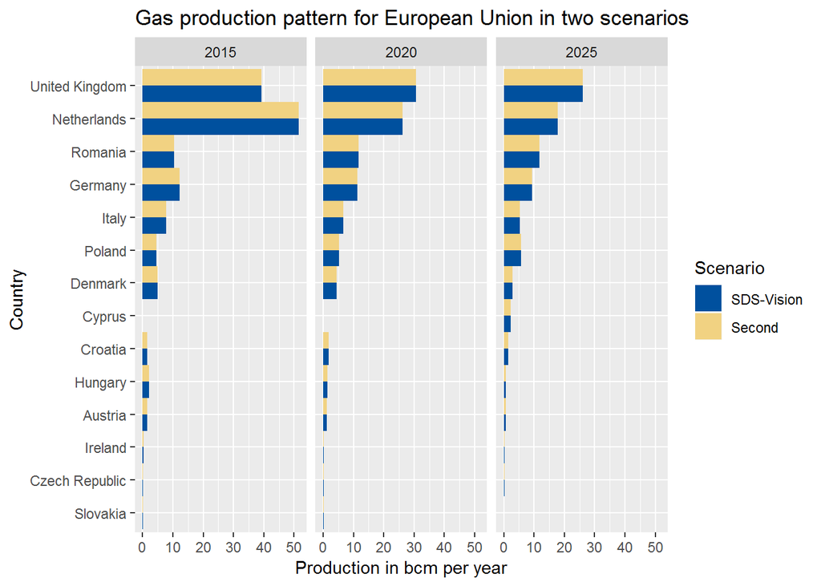

```r
ggplot(
    # chose data
    data = filter(plot_data_EU, Type == "Prod" & Capacity > 0 & RGN == "EU"),
    aes(reorder(name, Capacity),
        y = Capacity, fill = Scen)
    ) +
  geom_bar(stat = "identity", position = "dodge", width = 1) +
  # add colour according to fill variable
  scale_fill_manual(values = col_scen,
                    name = "Scenario"
  ) +
  # title and axis labels
  labs(title = "Gas production pattern for European Union in two scenarios",
       x = "Country",
       y ="Production in bcm per year") +
  fonts +
  theme_plot +
  coord_flip() +
  facet_wrap(~Year)
```

- bar plot for consumption (world, EU, ROE)
- line plot for production and consumption (world, Europe)

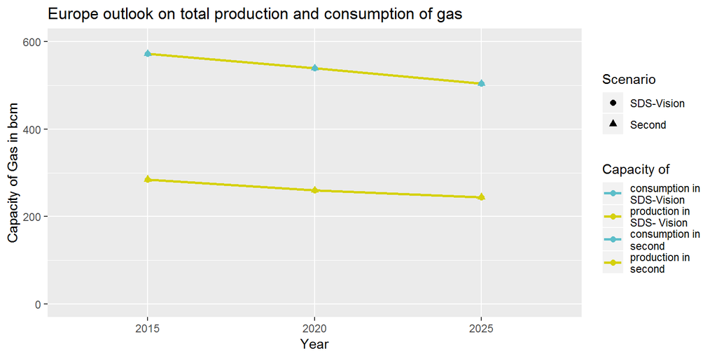

```r
plot_data_EU %>%
  group_by(Scen, Type, Year) %>%
  summarise(Capacity = sum(Capacity)) %>%
  ungroup() %>%
  filter(Type != "Trade")%>%
  ggplot(aes(
    x = Year, y = Capacity,
    colour = Type, shape = Scen,
    group = interaction(Type, Scen))
    ) +
  geom_line(aes(color = Scen),size=1) +
  geom_point(aes(shape = Scen),size=2) +
  theme_plot+
  scale_colour_manual(values = rep(col_cap, times=2),
                      name = "Capacity of",
                      labels=c(
                        "consumption in \nSDS-Vision",
                        "production in \nSDS- Vision",
                        "consumption in \nsecond",
                        "production in \nsecond"
                        )
  ) +
  #fonts +
  labs(title = "Europe outlook on total production and consumption of gas",
       y = "Capacity of Gas in bcm",
       shape = "Scenario"
       ) +
  ylim(0,600)
```

If there is a wish to change any layout or visualization methods, the script allows for changes in all attributes.

The last item within both files `static_plots_REGIONS.R` and `static_plots_Europe.R` is a loop that creates interactive maps using the leaflet package. The number of maps created equals the number of scenarios run in the model. These maps visualize bar plots for consumption and production in EU countries or world regions evolving over time. In addition, there is a visualization of trade flows for trade between world regions.

[^1]: This may take a while when executed for the first time. R will download and install all necessary packages.
[^2]: If only a chunk of the code needs to be run, mark the code and press Ctrl + Enter; for only one line, move the cursor to the line and press `Run`